# Проект: Прототип модели машинного обучения для «Оператора связи "Ниединогоразрыва.ком"».

- Оператор связи «Ниединогоразрыва.ком» хочет научиться прогнозировать отток клиентов. Если выяснится, что пользователь планирует уйти, ему будут предложены промокоды и специальные условия. Команда оператора собрала персональные данные о некоторых клиентах, информацию об их тарифах и договорах.

### Описание услуг

Оператор предоставляет два основных типа услуг:

1. Стационарную телефонную связь. Возможно подключение телефонного аппарата к нескольким линиям одновременно.
2. Интернет. Подключение может быть двух типов: через телефонную линию (DSL*,* от англ. *digital subscriber line*, «цифровая абонентская линия») или оптоволоконный кабель (*Fiber optic*).

Также доступны такие услуги:

1. Интернет-безопасность: антивирус (*DeviceProtection*) и блокировка небезопасных сайтов (*OnlineSecurity*);
2. Выделенная линия технической поддержки (*TechSupport*);
3. Облачное хранилище файлов для резервного копирования данных (*OnlineBackup*);
4. Стриминговое телевидение (*StreamingTV*) и каталог фильмов (*StreamingMovies*).

За услуги клиенты могут платить каждый месяц или заключить договор на 1–2 года. Доступны различные способы расчёта и возможность получения электронного чека.

## План проекта:

##### Цель:

Построить модель для прогнозирования оттока клиентов.

##### Условия:

- Использовать бизнес-метрики:
1. Основная метрика: AUC-ROC (метрика, которая учитывает возможность балансировать между false posititve и false negative.); целевое значение AUC-ROC >= 0.85
2. Дополнительная метрика: Accuracy;
- Использовать значение RANDOM_STATE = 100423;
- Размер тестовой выборки: test_size = 0.25;
- Проверить корреляцию числовых признаков на наличие мультиколлинеарности;
- Должны быть рассмотрены как минимум две (а лучше три) модели машинного обучения, например случайный лес и градиентный бустинг. При использовании только двух моделей нельзя использовать две вариации градиентного бустинга.

##### Задачи:

1. На тренировочной выборке обучить разные модели, одна из которых — бустинг (LightGBM, Catboost), и как минимум одна — не бустинг (RandomForest); для каждой модели попробовать разные гиперпараметры;
2. Проанализировать AUC-ROC и Accuracy моделей;
3. Опираясь на критерии заказчика, выбрать лучшую модель, проверить её качество на тестовой выборке.

##### Этапы исследования:

1. Общий обзор данных (выведение общей информации, корректировка названия столбов при необходимости, выведение примера таблицы);
2. Провести предобработку данных (поиск дубликатов, анализ пропусков, объединение датасетов, выявление `target` и `features`);
3. Анализ данных (непосредственно на данном этапе мы будем выполнять поставленные нами задачи);
4. Вывод и заключение.

По ходу выполнения всех этапов проекта мы будем делать промежуточные выводы, которые помогут нам сделать конечные выводы.

### Описание данных

Данные состоят из файлов, полученных из разных источников:

- `contract_new.csv` — информация о договоре;
- `personal_new.csv` — персональные данные клиента;
- `internet_new.csv` — информация об интернет-услугах;
- `phone_new.csv` — информация об услугах телефонии.

Во всех файлах столбец `customerID` содержит код клиента.

Информация о договорах актуальна на 1 февраля 2020.

Данные также находятся в тренажёре, в папке `/datasets/`.

#### Обозначения признаков

1. BeginDate – дата начала пользования услугами;
2. EndDate – дата окончания пользования услугами;
3. Type – тип оплаты: ежемесячный, годовой и тд;
4. PaperlessBilling – безналичный расчет;
5. PaymentMethod – способ оплаты;
6. MonthlyCharges – ежемесячные траты на услуги;
7. TotalCharges – всего потрачено денег на услуги;
8. Dependents – наличие иждивенцев;
9. Senior Citizen – наличие пенсионного статуса по возрасту;
10. Partner – наличие супруга(и);
11. MultipleLines – наличие возможности ведения параллельных линий во время звонка.

## Подготовка, исследовательский анализ, предобработка данных.

```python
import phik
import pandas_profiling
from sklearn.preprocessing import (
    OneHotEncoder,
    OrdinalEncoder,
    StandardScaler
)
from sklearn.model_selection import (
    train_test_split,
    GridSearchCV,
    cross_val_score,
    cross_val_predict
)
from sklearn.metrics import (
    roc_auc_score,
    accuracy_score,
    roc_curve
)
from catboost import cv, CatBoostClassifier
from lightgbm import LGBMClassifier
from sklearn.ensemble import RandomForestClassifier
import copy
import datetime
import random
import time
import warnings

import matplotlib.pyplot as plt
import numpy as np
import pandas as pd
import seaborn as sns
import sweetviz as sv

from IPython.display import display

from pandarallel import pandarallel
pandarallel.initialize(progress_bar=True)
```

```
INFO: Pandarallel will run on 4 workers.
INFO: Pandarallel will use standard multiprocessing data transfer (pipe) to transfer data between the main process and workers.
```

```python
df_contract = pd.read_csv(
    '/Users/kolotukhin.md/Downloads/jupyter_notebook/14/final_provider/contract_new.csv')
df_personal = pd.read_csv(
    '/Users/kolotukhin.md/Downloads/jupyter_notebook/14/final_provider/personal_new.csv')
df_internet = pd.read_csv(
    '/Users/kolotukhin.md/Downloads/jupyter_notebook/14/final_provider/internet_new.csv')
df_phone = pd.read_csv(
    '/Users/kolotukhin.md/Downloads/jupyter_notebook/14/final_provider/phone_new.csv')

pd.set_option('display.max_columns', None)
pd.set_option('display.max_rows', None)
```

- С помощью `sweetviz` создадим сводный отчет по каждому из датасетов.

```python
# report = sv.analyze([df_contract, "Info_df_contract_1.0"])
```

```python
# report = sv.analyze([df_personal, "Info_df_personal_1.0"])
```

```python
# report = sv.analyze([df_internet, "Info_df_internet_1.0"])
```

```python
# report = sv.analyze([df_phone, "Info_df_phone_1.0"])
```

- Выведем сводную информацию о таблице и выведем первые 10 строк таблицы

```python
df_list = [df_contract, df_personal, df_internet, df_phone]
for i in df_list:
    display(i.head(10))
    print(i.info())
    print()
    print(i.shape)
    print()
    print(i.dtypes)
```

|  | customerID | BeginDate | EndDate | Type | PaperlessBilling | PaymentMethod | MonthlyCharges | TotalCharges |
| --- | --- | --- | --- | --- | --- | --- | --- | --- |
| 0 | 7590-VHVEG | 2020-01-01 | No | Month-to-month | Yes | Electronic check | 29.85 | 31.04 |
| 1 | 5575-GNVDE | 2017-04-01 | No | One year | No | Mailed check | 56.95 | 2071.84 |
| 2 | 3668-QPYBK | 2019-10-01 | No | Month-to-month | Yes | Mailed check | 53.85 | 226.17 |
| 3 | 7795-CFOCW | 2016-05-01 | No | One year | No | Bank transfer (automatic) | 42.30 | 1960.6 |
| 4 | 9237-HQITU | 2019-09-01 | No | Month-to-month | Yes | Electronic check | 70.70 | 353.5 |
| 5 | 9305-CDSKC | 2019-03-01 | No | Month-to-month | Yes | Electronic check | 99.65 | 1150.96 |
| 6 | 1452-KIOVK | 2018-04-01 | No | Month-to-month | Yes | Credit card (automatic) | 89.10 | 2058.21 |
| 7 | 6713-OKOMC | 2019-04-01 | No | Month-to-month | No | Mailed check | 29.75 | 300.48 |
| 8 | 7892-POOKP | 2017-07-01 | No | Month-to-month | Yes | Electronic check | 104.80 | 3573.68 |
| 9 | 6388-TABGU | 2014-12-01 | 2017-05-01 | One year | No | Bank transfer (automatic) | 56.15 | 1628.35 |

```
<class 'pandas.core.frame.DataFrame'>
RangeIndex: 7043 entries, 0 to 7042
Data columns (total 8 columns):
 #   Column            Non-Null Count  Dtype
---  ------            --------------  -----
 0   customerID        7043 non-null   object
 1   BeginDate         7043 non-null   object
 2   EndDate           7043 non-null   object
 3   Type              7043 non-null   object
 4   PaperlessBilling  7043 non-null   object
 5   PaymentMethod     7043 non-null   object
 6   MonthlyCharges    7043 non-null   float64
 7   TotalCharges      7043 non-null   object
dtypes: float64(1), object(7)
memory usage: 440.3+ KB
None

(7043, 8)

customerID           object
BeginDate            object
EndDate              object
Type                 object
PaperlessBilling     object
PaymentMethod        object
MonthlyCharges      float64
TotalCharges         object
dtype: object
```

|  | customerID | gender | SeniorCitizen | Partner | Dependents |
| --- | --- | --- | --- | --- | --- |
| 0 | 7590-VHVEG | Female | 0 | Yes | No |
| 1 | 5575-GNVDE | Male | 0 | No | No |
| 2 | 3668-QPYBK | Male | 0 | No | No |
| 3 | 7795-CFOCW | Male | 0 | No | No |
| 4 | 9237-HQITU | Female | 0 | No | No |
| 5 | 9305-CDSKC | Female | 0 | No | No |
| 6 | 1452-KIOVK | Male | 0 | No | Yes |
| 7 | 6713-OKOMC | Female | 0 | No | No |
| 8 | 7892-POOKP | Female | 0 | Yes | No |
| 9 | 6388-TABGU | Male | 0 | No | Yes |

```
<class 'pandas.core.frame.DataFrame'>
RangeIndex: 7043 entries, 0 to 7042
Data columns (total 5 columns):
 #   Column         Non-Null Count  Dtype
---  ------         --------------  -----
 0   customerID     7043 non-null   object
 1   gender         7043 non-null   object
 2   SeniorCitizen  7043 non-null   int64
 3   Partner        7043 non-null   object
 4   Dependents     7043 non-null   object
dtypes: int64(1), object(4)
memory usage: 275.2+ KB
None

(7043, 5)

customerID       object
gender           object
SeniorCitizen     int64
Partner          object
Dependents       object
dtype: object
```

|  | customerID | InternetService | OnlineSecurity | OnlineBackup | DeviceProtection | TechSupport | StreamingTV | StreamingMovies |
| --- | --- | --- | --- | --- | --- | --- | --- | --- |
| 0 | 7590-VHVEG | DSL | No | Yes | No | No | No | No |
| 1 | 5575-GNVDE | DSL | Yes | No | Yes | No | No | No |
| 2 | 3668-QPYBK | DSL | Yes | Yes | No | No | No | No |
| 3 | 7795-CFOCW | DSL | Yes | No | Yes | Yes | No | No |
| 4 | 9237-HQITU | Fiber optic | No | No | No | No | No | No |
| 5 | 9305-CDSKC | Fiber optic | No | No | Yes | No | Yes | Yes |
| 6 | 1452-KIOVK | Fiber optic | No | Yes | No | No | Yes | No |
| 7 | 6713-OKOMC | DSL | Yes | No | No | No | No | No |
| 8 | 7892-POOKP | Fiber optic | No | No | Yes | Yes | Yes | Yes |
| 9 | 6388-TABGU | DSL | Yes | Yes | No | No | No | No |

```
<class 'pandas.core.frame.DataFrame'>
RangeIndex: 5517 entries, 0 to 5516
Data columns (total 8 columns):
 #   Column            Non-Null Count  Dtype
---  ------            --------------  -----
 0   customerID        5517 non-null   object
 1   InternetService   5517 non-null   object
 2   OnlineSecurity    5517 non-null   object
 3   OnlineBackup      5517 non-null   object
 4   DeviceProtection  5517 non-null   object
 5   TechSupport       5517 non-null   object
 6   StreamingTV       5517 non-null   object
 7   StreamingMovies   5517 non-null   object
dtypes: object(8)
memory usage: 344.9+ KB
None

(5517, 8)

customerID          object
InternetService     object
OnlineSecurity      object
OnlineBackup        object
DeviceProtection    object
TechSupport         object
StreamingTV         object
StreamingMovies     object
dtype: object
```

|  | customerID | MultipleLines |
| --- | --- | --- |
| 0 | 5575-GNVDE | No |
| 1 | 3668-QPYBK | No |
| 2 | 9237-HQITU | No |
| 3 | 9305-CDSKC | Yes |
| 4 | 1452-KIOVK | Yes |
| 5 | 7892-POOKP | Yes |
| 6 | 6388-TABGU | No |
| 7 | 9763-GRSKD | No |
| 8 | 7469-LKBCI | No |
| 9 | 8091-TTVAX | Yes |

```
<class 'pandas.core.frame.DataFrame'>
RangeIndex: 6361 entries, 0 to 6360
Data columns (total 2 columns):
 #   Column         Non-Null Count  Dtype
---  ------         --------------  -----
 0   customerID     6361 non-null   object
 1   MultipleLines  6361 non-null   object
dtypes: object(2)
memory usage: 99.5+ KB
None

(6361, 2)

customerID       object
MultipleLines    object
dtype: object
```

- Объединим датасеты

```python
df_merge = pd.merge(df_contract, df_personal, how='left', on='customerID')
df_merge = pd.merge(df_merge, df_internet, how='left', on='customerID')
df_merge = pd.merge(df_merge, df_phone, how='left', on='customerID')
```

- Приведем название столбцов в стиль "snake_case" и в нижний регистр
- Выведем сводную информацию о таблице
- Выведем тип данных

```python
df_merge.columns = df_merge.columns.str.replace(
    r"([A-Z])", r" \1").str.lower().str.replace(' ', '_').str[1:]

print(df_merge.shape)
print()

# вывести тип данных
print(df_merge.dtypes)
```

```
(7043, 20)

ustomer_i_d           object
begin_date            object
end_date              object
type                  object
paperless_billing     object
payment_method        object
monthly_charges      float64
total_charges         object
ender                 object
senior_citizen         int64
partner               object
dependents            object
internet_service      object
online_security       object
online_backup         object
device_protection     object
tech_support          object
streaming_t_v         object
streaming_movies      object
multiple_lines        object
dtype: object
```

- Переименуем столбец ustomer_i_d согласно правилам стиля Python

```python
df_merge = df_merge.rename(columns={'ustomer_i_d': 'customer_id',
                                    'streaming_t_v': 'streaming_tv',
                                    'ender': 'gender'}
                           )

print(df_merge.dtypes)
```

```
customer_id           object
begin_date            object
end_date              object
type                  object
paperless_billing     object
payment_method        object
monthly_charges      float64
total_charges         object
gender                object
senior_citizen         int64
partner               object
dependents            object
internet_service      object
online_security       object
online_backup         object
device_protection     object
tech_support          object
streaming_tv          object
streaming_movies      object
multiple_lines        object
dtype: object
```

- Проверим на дубликаты

```python
print(df_merge.duplicated().sum())
```

```
0
```

- Выведем на экран информацию о пропусках в данных

```python
pd.DataFrame(df_merge.isna().mean()
             .to_frame(name='Пропуски')
             .query('Пропуски > 0')['Пропуски'])\
    .style.background_gradient('coolwarm')\
    .format({'Пропуски': '{:.2%}'})
```

|  | Пропуски |
| --- | --- |
| internet_service | 21.67% |
| online_security | 21.67% |
| online_backup | 21.67% |
| device_protection | 21.67% |
| tech_support | 21.67% |
| streaming_tv | 21.67% |
| streaming_movies | 21.67% |
| multiple_lines | 9.68% |

- Предположим, что пустые значения в объединенной таблице в тех ячейках, где значений нет. Другими словами присвоим этим ячейкам значения "No". И затем снова проверим наши данные на пропуски.

```python
df_merge = df_merge.fillna('No')
```

- Выведем на экран информацию о пропусках в данных после проведенной обработки

```python
pd.DataFrame(df_merge.isna().mean()
             .to_frame(name='Пропуски')
             .query('Пропуски > 0')['Пропуски'])\
    .style.background_gradient('coolwarm')\
    .format({'Пропуски': '{:.2%}'})
```

|  | Пропуски |
| --- | --- |

- Выведем 10 строк объединенной таблицы

```python
display(df_merge.head(10))
```

|  | customer_id | begin_date | end_date | type | paperless_billing | payment_method | monthly_charges | total_charges | gender | senior_citizen | partner | dependents | internet_service | online_security | online_backup | device_protection | tech_support | streaming_tv | streaming_movies | multiple_lines |
| --- | --- | --- | --- | --- | --- | --- | --- | --- | --- | --- | --- | --- | --- | --- | --- | --- | --- | --- | --- | --- |
| 0 | 7590-VHVEG | 2020-01-01 | No | Month-to-month | Yes | Electronic check | 29.85 | 31.04 | Female | 0 | Yes | No | DSL | No | Yes | No | No | No | No | No |
| 1 | 5575-GNVDE | 2017-04-01 | No | One year | No | Mailed check | 56.95 | 2071.84 | Male | 0 | No | No | DSL | Yes | No | Yes | No | No | No | No |
| 2 | 3668-QPYBK | 2019-10-01 | No | Month-to-month | Yes | Mailed check | 53.85 | 226.17 | Male | 0 | No | No | DSL | Yes | Yes | No | No | No | No | No |
| 3 | 7795-CFOCW | 2016-05-01 | No | One year | No | Bank transfer (automatic) | 42.30 | 1960.6 | Male | 0 | No | No | DSL | Yes | No | Yes | Yes | No | No | No |
| 4 | 9237-HQITU | 2019-09-01 | No | Month-to-month | Yes | Electronic check | 70.70 | 353.5 | Female | 0 | No | No | Fiber optic | No | No | No | No | No | No | No |
| 5 | 9305-CDSKC | 2019-03-01 | No | Month-to-month | Yes | Electronic check | 99.65 | 1150.96 | Female | 0 | No | No | Fiber optic | No | No | Yes | No | Yes | Yes | Yes |
| 6 | 1452-KIOVK | 2018-04-01 | No | Month-to-month | Yes | Credit card (automatic) | 89.10 | 2058.21 | Male | 0 | No | Yes | Fiber optic | No | Yes | No | No | Yes | No | Yes |
| 7 | 6713-OKOMC | 2019-04-01 | No | Month-to-month | No | Mailed check | 29.75 | 300.48 | Female | 0 | No | No | DSL | Yes | No | No | No | No | No | No |
| 8 | 7892-POOKP | 2017-07-01 | No | Month-to-month | Yes | Electronic check | 104.80 | 3573.68 | Female | 0 | Yes | No | Fiber optic | No | No | Yes | Yes | Yes | Yes | Yes |
| 9 | 6388-TABGU | 2014-12-01 | 2017-05-01 | One year | No | Bank transfer (automatic) | 56.15 | 1628.35 | Male | 0 | No | Yes | DSL | Yes | Yes | No | No | No | No | No |

- Создадим новый признак "exited". Если на 1 февраля 2020 клиент не закончил свое сотрудничество с компанией, тогда придаем значение "0". Если же клиент прекратил сотрудничество с компанией, тогда придаем значение "1".

```python
df_merge['exited'] = df_merge['end_date'].apply(
    lambda x: 0 if x == 'No' else 1)
```

```python
df_merge['end_date'] = df_merge['end_date'].replace('No', '2020-02-01')
```

```python
df_merge['end_date'] = pd.to_datetime(df_merge['end_date'])
df_merge['begin_date'] = pd.to_datetime(df_merge['begin_date'])
df_merge['duration'] = (
    (df_merge['end_date'] - df_merge['begin_date']) / np.timedelta64(1, 'D')).round()
df_merge['duration'] = df_merge['duration'].astype(int)
```

- Удалим столбцы, не несущие смысловой нагрузки для дальнейшего анализа.

```python
df_merge = df_merge.drop(columns=['begin_date',
                                  'end_date']
                         )
```

- Сделаем индексацию таблицы по столбцу 'customer_id'

```python
df_merge = df_merge.set_index('customer_id')
```

- Выведем сводную информацию

```python
display(df_merge.info())
```

```
<class 'pandas.core.frame.DataFrame'>
Index: 7043 entries, 7590-VHVEG to 3186-AJIEK
Data columns (total 19 columns):
 #   Column             Non-Null Count  Dtype
---  ------             --------------  -----
 0   type               7043 non-null   object
 1   paperless_billing  7043 non-null   object
 2   payment_method     7043 non-null   object
 3   monthly_charges    7043 non-null   float64
 4   total_charges      7043 non-null   object
 5   gender             7043 non-null   object
 6   senior_citizen     7043 non-null   int64
 7   partner            7043 non-null   object
 8   dependents         7043 non-null   object
 9   internet_service   7043 non-null   object
 10  online_security    7043 non-null   object
 11  online_backup      7043 non-null   object
 12  device_protection  7043 non-null   object
 13  tech_support       7043 non-null   object
 14  streaming_tv       7043 non-null   object
 15  streaming_movies   7043 non-null   object
 16  multiple_lines     7043 non-null   object
 17  exited             7043 non-null   int64
 18  duration           7043 non-null   int64
dtypes: float64(1), int64(3), object(15)
memory usage: 1.1+ MB
```

```
None
```

- Выведем 10 строк объединенной таблицы после обработки данных

```python
display(df_merge.head(10))
```

| customer_id | type | paperless_billing | payment_method | monthly_charges | total_charges | gender | senior_citizen | partner | dependents | internet_service | online_security | online_backup | device_protection | tech_support | streaming_tv | streaming_movies | multiple_lines | exited | duration |
| --- | --- | --- | --- | --- | --- | --- | --- | --- | --- | --- | --- | --- | --- | --- | --- | --- | --- | --- | --- |
| 7590-VHVEG | Month-to-month | Yes | Electronic check | 29.85 | 31.04 | Female | 0 | Yes | No | DSL | No | Yes | No | No | No | No | No | 0 | 31 |
| 5575-GNVDE | One year | No | Mailed check | 56.95 | 2071.84 | Male | 0 | No | No | DSL | Yes | No | Yes | No | No | No | No | 0 | 1036 |
| 3668-QPYBK | Month-to-month | Yes | Mailed check | 53.85 | 226.17 | Male | 0 | No | No | DSL | Yes | Yes | No | No | No | No | No | 0 | 123 |
| 7795-CFOCW | One year | No | Bank transfer (automatic) | 42.30 | 1960.6 | Male | 0 | No | No | DSL | Yes | No | Yes | Yes | No | No | No | 0 | 1371 |
| 9237-HQITU | Month-to-month | Yes | Electronic check | 70.70 | 353.5 | Female | 0 | No | No | Fiber optic | No | No | No | No | No | No | No | 0 | 153 |
| 9305-CDSKC | Month-to-month | Yes | Electronic check | 99.65 | 1150.96 | Female | 0 | No | No | Fiber optic | No | No | Yes | No | Yes | Yes | Yes | 0 | 337 |
| 1452-KIOVK | Month-to-month | Yes | Credit card (automatic) | 89.10 | 2058.21 | Male | 0 | No | Yes | Fiber optic | No | Yes | No | No | Yes | No | Yes | 0 | 671 |
| 6713-OKOMC | Month-to-month | No | Mailed check | 29.75 | 300.48 | Female | 0 | No | No | DSL | Yes | No | No | No | No | No | No | 0 | 306 |
| 7892-POOKP | Month-to-month | Yes | Electronic check | 104.80 | 3573.68 | Female | 0 | Yes | No | Fiber optic | No | No | Yes | Yes | Yes | Yes | Yes | 0 | 945 |
| 6388-TABGU | One year | No | Bank transfer (automatic) | 56.15 | 1628.35 | Male | 0 | No | Yes | DSL | Yes | Yes | No | No | No | No | No | 1 | 882 |

- Выведем уникальные значения каждого из столбцов с помощью функции

```python
def unique_values(df):
    for column in df.columns:
        print(f"Unique values in {column}:")
        print(df_merge[column].unique())
        print("")


print(unique_values(df_merge))
```

```
Unique values in type:
['Month-to-month' 'One year' 'Two year']

Unique values in paperless_billing:
['Yes' 'No']

Unique values in payment_method:
['Electronic check' 'Mailed check' 'Bank transfer (automatic)'
 'Credit card (automatic)']

Unique values in monthly_charges:
[29.85 56.95 53.85 ... 63.1  44.2  78.7 ]

Unique values in total_charges:
['31.04' '2071.84' '226.17' ... '325.6' '520.8' '7251.82']

Unique values in gender:
['Female' 'Male']

Unique values in senior_citizen:
[0 1]

Unique values in partner:
['Yes' 'No']

Unique values in dependents:
['No' 'Yes']

Unique values in internet_service:
['DSL' 'Fiber optic' 'No']

Unique values in online_security:
['No' 'Yes']

Unique values in online_backup:
['Yes' 'No']

Unique values in device_protection:
['No' 'Yes']

```

[output cut: 21 more lines]

```
 1431  485 1034  975 1551  700  942 1734 1798  730 1340 1216  943 1066
 1096 1645 1642  273 1553 1219  303 1126 1887 2071  426 2040  911 2132
 1736  640 1489 1675 1218 1522 1186  608  214   59   61    0 1035 1341
 1917 1676 1795 1155  913  182  820 1430  976  579  669  486  668  760
 1611  912 1552  275 2038 1187 1068 1003 1127 1124  274 1705  305 1308
 1491  762  335 1185  425  609 1004 2283 1005  181  489  304 1247 1065
  550  854 2070 1370  334  213  122  851  395  546  578  548  946  638
 1007  456  487 1372 1582 1064  972  974 1673 1217 1156  823 1765 1369
  791 1643  759  458 1249 1037 1644  852  790   28  212 1338  699  243
  183  515  731  366 1583 1188  850  577 1277  519  517 1400  915  151
  242 1278  607  393 1735 1339 1158 1704   30  944 1520  639  701 1125
 1311 2314 2068  672  121 1612  611 1399  454 1309  424   90 1550  547
 1915  336  516  821 2129  789   91  397 1402  703  244 2253  793]

None
```

- Выведем количество уникальных значений каждого из столбцов

```python
unique_counts = df_merge.nunique()
print(unique_counts)
```

```
type                    3
paperless_billing       2
payment_method          4
monthly_charges      1585
total_charges        6658
gender                  2
senior_citizen          2
partner                 2
dependents              2
internet_service        3
online_security         2
online_backup           2
device_protection       2
tech_support            2
streaming_tv            2
streaming_movies        2
multiple_lines          2
exited                  2
duration              251
dtype: int64
```

```python
display(df_merge.info())
```

```
<class 'pandas.core.frame.DataFrame'>
Index: 7043 entries, 7590-VHVEG to 3186-AJIEK
Data columns (total 19 columns):
 #   Column             Non-Null Count  Dtype
---  ------             --------------  -----
 0   type               7043 non-null   object
 1   paperless_billing  7043 non-null   object
 2   payment_method     7043 non-null   object
 3   monthly_charges    7043 non-null   float64
 4   total_charges      7043 non-null   object
 5   gender             7043 non-null   object
 6   senior_citizen     7043 non-null   int64
 7   partner            7043 non-null   object
 8   dependents         7043 non-null   object
 9   internet_service   7043 non-null   object
 10  online_security    7043 non-null   object
 11  online_backup      7043 non-null   object
 12  device_protection  7043 non-null   object
 13  tech_support       7043 non-null   object
 14  streaming_tv       7043 non-null   object
 15  streaming_movies   7043 non-null   object
 16  multiple_lines     7043 non-null   object
 17  exited             7043 non-null   int64
 18  duration           7043 non-null   int64
dtypes: float64(1), int64(3), object(15)
memory usage: 1.1+ MB
```

```
None
```

- Выведем список (отсортированный по возрастанию) уникальных значений столбца "total_charges", чтобы оценить наличие аномальных значений в этих столбцах и выяснить из-за чего у данного столбца тип данных: object.

```python
unique_values_t_c = df_merge["total_charges"].unique()
unique_values_sorted_t_c = sorted(unique_values_t_c)
print(unique_values_sorted_t_c)
```

[output not shown]

- Выведем на экран строки со значением столбца "total_charges" равным пробелу.

```python
df_merge.query("total_charges == ' '")
```

| customer_id | type | paperless_billing | payment_method | monthly_charges | total_charges | gender | senior_citizen | partner | dependents | internet_service | online_security | online_backup | device_protection | tech_support | streaming_tv | streaming_movies | multiple_lines | exited | duration |
| --- | --- | --- | --- | --- | --- | --- | --- | --- | --- | --- | --- | --- | --- | --- | --- | --- | --- | --- | --- |
| 4472-LVYGI | Two year | Yes | Bank transfer (automatic) | 52.55 |  | Female | 0 | Yes | Yes | DSL | Yes | No | Yes | Yes | Yes | No | No | 0 | 0 |
| 3115-CZMZD | Two year | No | Mailed check | 20.25 |  | Male | 0 | No | Yes | No | No | No | No | No | No | No | No | 0 | 0 |
| 5709-LVOEQ | Two year | No | Mailed check | 80.85 |  | Female | 0 | Yes | Yes | DSL | Yes | Yes | Yes | No | Yes | Yes | No | 0 | 0 |
| 4367-NUYAO | Two year | No | Mailed check | 25.75 |  | Male | 0 | Yes | Yes | No | No | No | No | No | No | No | Yes | 0 | 0 |
| 1371-DWPAZ | Two year | No | Credit card (automatic) | 56.05 |  | Female | 0 | Yes | Yes | DSL | Yes | Yes | Yes | Yes | Yes | No | No | 0 | 0 |
| 7644-OMVMY | Two year | No | Mailed check | 19.85 |  | Male | 0 | Yes | Yes | No | No | No | No | No | No | No | No | 0 | 0 |
| 3213-VVOLG | Two year | No | Mailed check | 25.35 |  | Male | 0 | Yes | Yes | No | No | No | No | No | No | No | Yes | 0 | 0 |
| 2520-SGTTA | Two year | No | Mailed check | 20.00 |  | Female | 0 | Yes | Yes | No | No | No | No | No | No | No | No | 0 | 0 |
| 2923-ARZLG | One year | Yes | Mailed check | 19.70 |  | Male | 0 | Yes | Yes | No | No | No | No | No | No | No | No | 0 | 0 |
| 4075-WKNIU | Two year | No | Mailed check | 73.35 |  | Female | 0 | Yes | Yes | DSL | No | Yes | Yes | Yes | Yes | No | Yes | 0 | 0 |
| 2775-SEFEE | Two year | Yes | Bank transfer (automatic) | 61.90 |  | Male | 0 | No | Yes | DSL | Yes | Yes | No | Yes | No | No | Yes | 0 | 0 |

- Мы вывели строки со значением столца "total_charges" равным пробелу. В этих строках значение столца "duration" равно нулю. Предположим, что тут есть прямая зависимость. Выведем количество строк с тем и другим значением, чтобы подтвердить наше предположение.

```python
count_space = (df_merge['total_charges'] == " ").sum()
print(count_space)
```

```
11
```

```python
count_zero = (df_merge['duration'] == 0).sum()
print(count_zero)
```

```
11
```

- Наше предположение оказалось верным. Количество строк с такими значениями очень маленькое. Поэтому их удаление не повлечет для нас серьезных последствий. Удалим строки с этими значениями.

```python
df_merge = df_merge.drop(df_merge[df_merge['duration'] == 0].index)
```

```python
# изменим тип данных на "float64", так как мы удалили пробелы.
df_merge['total_charges'] = df_merge['total_charges'].astype('float64')
```

```python
# изменим тип данных на "object", так как это бинарный признак.
df_merge['senior_citizen'] = df_merge['senior_citizen'].astype('object')
```

```python
# выведем общую информацию о датасете
display(df_merge.info())
```

```
<class 'pandas.core.frame.DataFrame'>
Index: 7032 entries, 7590-VHVEG to 3186-AJIEK
Data columns (total 19 columns):
 #   Column             Non-Null Count  Dtype
---  ------             --------------  -----
 0   type               7032 non-null   object
 1   paperless_billing  7032 non-null   object
 2   payment_method     7032 non-null   object
 3   monthly_charges    7032 non-null   float64
 4   total_charges      7032 non-null   float64
 5   gender             7032 non-null   object
 6   senior_citizen     7032 non-null   object
 7   partner            7032 non-null   object
 8   dependents         7032 non-null   object
 9   internet_service   7032 non-null   object
 10  online_security    7032 non-null   object
 11  online_backup      7032 non-null   object
 12  device_protection  7032 non-null   object
 13  tech_support       7032 non-null   object
 14  streaming_tv       7032 non-null   object
 15  streaming_movies   7032 non-null   object
 16  multiple_lines     7032 non-null   object
 17  exited             7032 non-null   int64
 18  duration           7032 non-null   int64
dtypes: float64(2), int64(2), object(15)
memory usage: 1.1+ MB
```

```
None
```

```python
df_numeric = df_merge[['monthly_charges',
                       'duration',
                       'total_charges']
                      ]
```

- Выведем статистические характеристики числовых признаков.

```python
df_numeric.describe()
```

|  | monthly_charges | duration | total_charges |
| --- | --- | --- | --- |
| count | 7032.000000 | 7032.000000 | 7032.000000 |
| mean | 64.798208 | 899.961320 | 2118.621822 |
| std | 30.085974 | 682.738777 | 2112.736199 |
| min | 18.250000 | 28.000000 | 19.050000 |
| 25% | 35.587500 | 276.000000 | 439.745000 |
| 50% | 70.350000 | 761.000000 | 1345.275000 |
| 75% | 89.862500 | 1461.000000 | 3239.317500 |
| max | 118.750000 | 2314.000000 | 9221.380000 |

- Построим гистограммы числовых признаков.

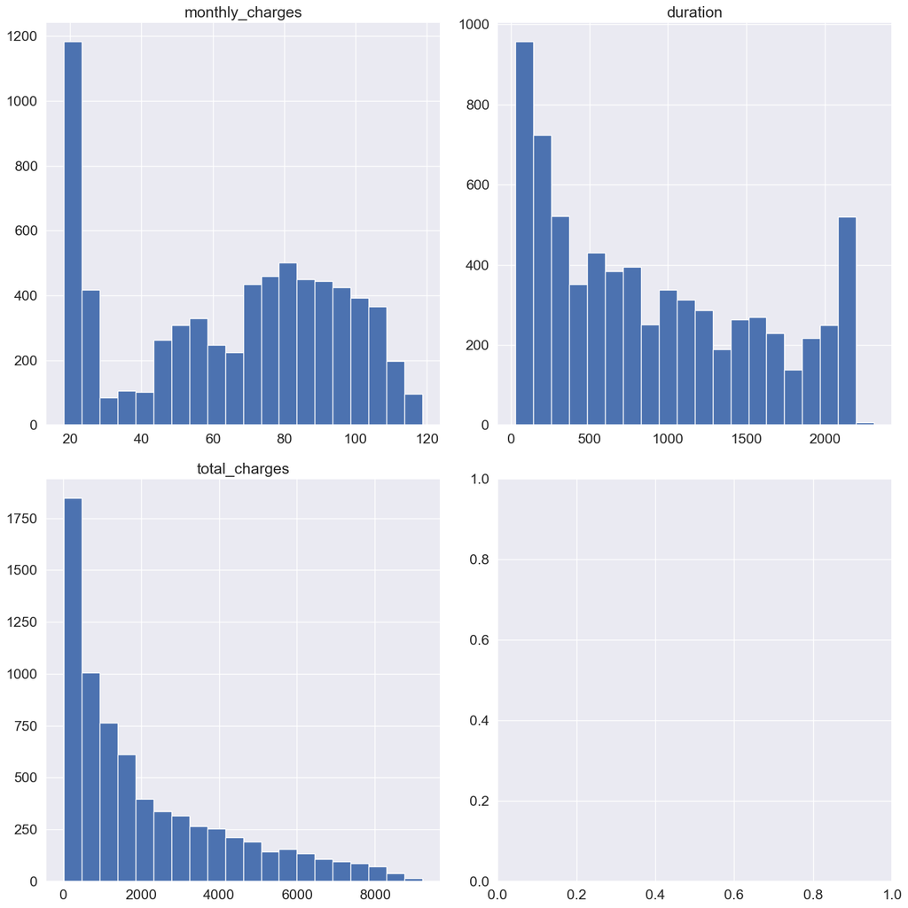

```python
fig, axs = plt.subplots(2, 2, figsize=(15, 15))
axs = axs.flatten()

for i, col in enumerate(df_numeric.columns):
    axs[i].hist(df_numeric[col], bins=20)
    axs[i].set_title(col)

# Увеличим размер шрифта названий графиков
for ax in axs:
    ax.title.set_fontsize(18)

plt.tight_layout()
plt.show()
plt.close()
```

- Построим "ящик с усами" для оценки выбросов.

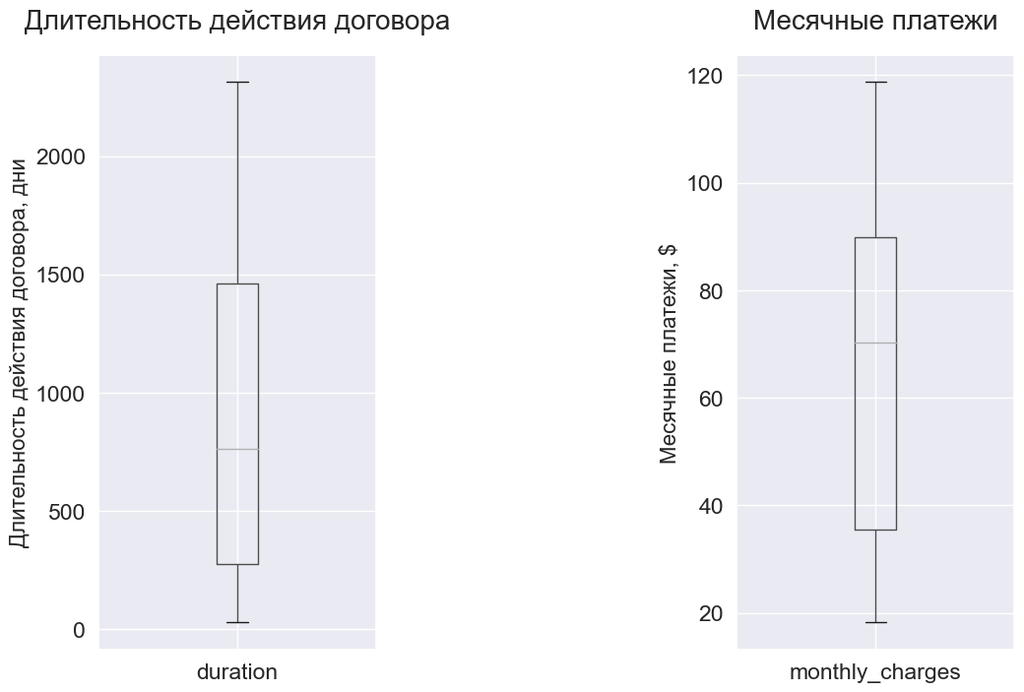

```python
fig, axes = plt.subplots(nrows=1, ncols=2, figsize=(
    12, 8), gridspec_kw={'wspace': 1.3})

# График длительности клиентов
df_numeric.boxplot(column=['duration'], ax=axes[0], grid=True)
axes[0].set_title('Длительность действия договора', y=1.03, fontsize=20)
axes[0].set_ylabel('Длительность действия договора, дни', fontsize=16)
axes[0].set_xlabel('')

# График месячных платежей
df_numeric.boxplot(column=['monthly_charges'], ax=axes[1], grid=True)
axes[1].set_title('Месячные платежи', y=1.03, fontsize=20)
axes[1].set_ylabel('Месячные платежи, $', fontsize=16)
axes[1].set_xlabel('')

plt.tight_layout()
plt.show()
plt.close()
```

```python
df_numeric = df_merge[['monthly_charges',
                       'exited',
                       'duration',
                       'total_charges']
                      ]
```

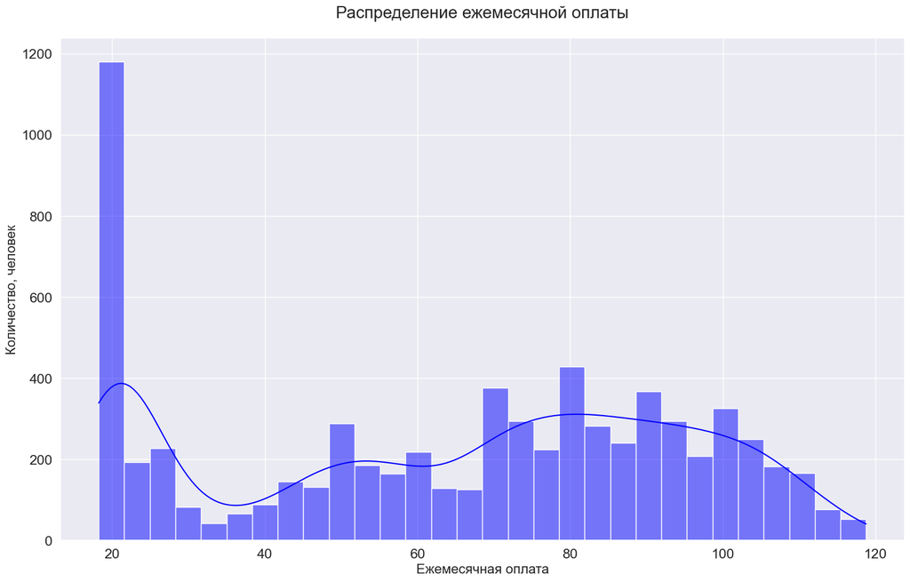

[figure not shown]

```python
# Одномерная гистограмма
fig, ax = plt.subplots(figsize=(18, 11))
sns.histplot(df_numeric['monthly_charges'], bins=30,
             kde=True, color='blue', alpha=0.5, ax=ax)
ax.set_title('Распределение ежемесячной оплаты', y=1.03, fontsize=20)
ax.set_xlabel('Ежемесячная оплата', fontsize=16)
ax.set_ylabel('Количество, человек', fontsize=16)
plt.show()
plt.close()
print()

# Ящик с усами
fig, ax = plt.subplots(figsize=(12, 8))
sns.boxplot(x='exited', y='duration', data=df_numeric, ax=ax)
ax.set_title(
    'Длительность действия договора клиентов по группам "ушедшие"/"оставшиеся"', y=1.03, fontsize=20)
ax.set_xlabel('Группа "ушедшие"/"оставшиеся"', fontsize=16)
ax.set_ylabel('Длительность, месяцы', fontsize=16)
plt.show()
plt.close()
```

- проверим качественные данные на мультикколлениарность, которая может ослабить статистическую мощность модели

```python
phik_overview = df_merge.drop(['monthly_charges',
                               'total_charges',
                               'senior_citizen',
                               'duration'], axis=1).phik_matrix()
phik_overview['exited'].sort_values(ascending=False)
```

```
interval columns not set, guessing: ['exited']
```

```
exited               1.000000
multiple_lines       0.261345
online_backup        0.229736
partner              0.227597
streaming_movies     0.221756
device_protection    0.218622
payment_method       0.214300
streaming_tv         0.200334
online_security      0.132914
tech_support         0.103933
type                 0.094622
paperless_billing    0.082789
internet_service     0.056279
dependents           0.048710
gender               0.008800
Name: exited, dtype: float64
```

- проверим количественные данные на мультикколлениарность, которая может ослабить статистическую мощность модели

```python
df_numeric = df_merge[['monthly_charges',
                       'total_charges',
                       'duration']
                      ]
```

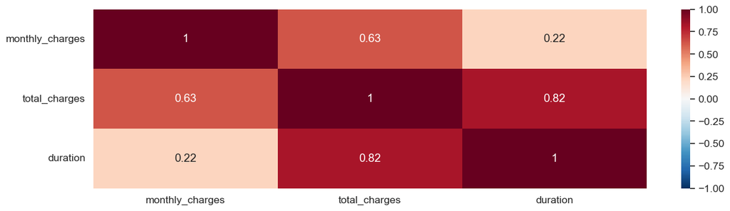

```python
sns.set(font_scale=1.15)
plt.figure(figsize=(15, 4))
sns.heatmap(
    df_numeric.corr(),
    cmap='RdBu_r',  # задаёт цветовую схему
    annot=True,  # рисует значения внутри ячеек
    vmin=-1, vmax=1)  # указывает начало цветовых кодов от -1 до 1.
plt.show()
plt.close()
```

```python
df_numeric = df_merge[['monthly_charges',
                       'exited',
                       'duration',
                       'total_charges']
                      ]
```

[figure not shown]

```python
g = sns.pairplot(df_numeric,
                 hue='exited',
                 diag_kind='kde',
                 diag_kws=dict(shade=True),
                 height=5,
                 palette=['#52BE80',
                          '#FF5733'],
                 plot_kws=dict(s=30,
                               linewidth=0.5)
                 )

g.fig.subplots_adjust(top=0.95)
g.fig.suptitle('Взаимосвязи между всеми парами числовых признаков',
               fontsize=23,
               y=1.0
               )

g.axes[1, 0].set_xlabel('Monthly Charges', fontsize=16)
g.axes[1, 0].set_ylabel('Total Charges', fontsize=16)

g.axes[2, 0].set_xlabel('Monthly Charges', fontsize=16)
g.axes[2, 0].set_ylabel('Duration', fontsize=16)

g.axes[2, 1].set_xlabel('Total Charges', fontsize=16)
g.axes[2, 1].set_ylabel('Duration', fontsize=16)

plt.show()
plt.close()
```

#### Выводы:

```python
df_numeric = df_merge[['monthly_charges',
                       'exited',
                       'duration',
                       'senior_citizen',
                       'total_charges']
                      ]
```

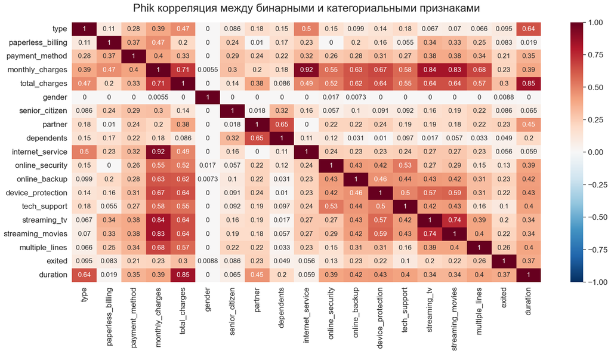

```python
sns.set(font_scale=1.5)
plt.figure(figsize=(22, 10))
sns.heatmap(
    df_merge.phik_matrix(interval_cols=df_numeric),
    cmap='RdBu_r',
    annot=True,
    annot_kws={"size": 14},
    vmin=-1, vmax=1)
plt.title("Phik корреляция между бинарными и категориальными признаками",
          fontsize=23, y=1.03)
plt.show()
plt.close()
```

- Мы видим сильную кореляцию между `total_charges` и `duration` , поэтому столбец `total_charges` удалим.

```python
df_merge = df_merge.drop('total_charges', axis=1)
```

- Проверим на дубликаты после проведенной обработки данных

```python
print(df_merge.duplicated().sum())
```

```
22
```

- Удалим дубликаты

```python
df_merge = df_merge.drop_duplicates()
```

- С помощью `sweetviz` создадим сводный отчет по объединенной таблице (df_merge)

```python
# report = sv.analyze([df_merge, "Info_df_merge_1.0"])
```

- С помощью `pandas_profiling.ProfileReport` создадим сводный отчет по объединенной таблице (df_merge)

```python
# pandas_profiling.ProfileReport(df_merge)
```

##### Вывод:

- среди качественных признаков мультикколлениарность не выявлена;
- вреди количественных признаков выявлена мультикколлениарность между двумя признакамми: `total_charges` и `duration` , поэтому столбец `total_charges` удалили;
- при анализе гистограмм числовых признаков и при анализе "ящиков с усами" для оценки выбросов аномалий не выявлено;
- подготовка, исследовательский анализ, предобработка данных выполнены, теперь можно начать подготовку и обработку данных.

## Подготовка данных

Объявим переменные:

- features_* — запишем в неё признаки;
- target_* — запишем в неё целевой признак.

1. " *_train " - обучающая (для обучения);
2. " *_test " - тестовая (для тестирования качества модели);

Соотношение выборок по размеру данных будет следующим:

- *_train :* _test = 3:1

```python
features = df_merge.drop(['exited'], axis=1)
target = df_merge['exited']

features_train, features_test, target_train, target_test = train_test_split(
    features, target, test_size=0.25, random_state=100423)
```

```python
# категориальные признаки для OHE
ohe_features = features_train.select_dtypes(include='object').columns.to_list()
```

```python
# численные признаки
num_features = features_train.select_dtypes(exclude='object').columns.to_list()
```

```python
features_train_ohe = features_train.copy()

features_test_ohe = features_test.copy()
```

```python
# получились одинаковые признаки в тренировочной и тестовой выборках
(features_train_ohe.columns != features_test_ohe.columns).sum()
```

```
0
```

```python
display(df_merge.columns)
```

```
Index(['type', 'paperless_billing', 'payment_method', 'monthly_charges',
       'gender', 'senior_citizen', 'partner', 'dependents', 'internet_service',
       'online_security', 'online_backup', 'device_protection', 'tech_support',
       'streaming_tv', 'streaming_movies', 'multiple_lines', 'exited',
       'duration'],
      dtype='object')
```

```python
# drop='first' удаляет первый признак из закодированных:
# таким образом обходим dummy-ловушку
# задаём handle_unknown='ignore':
# игнорируется ранее невстречающиеся значения признака (при transform)
encoder_ohe = OneHotEncoder(
    drop='first', handle_unknown='ignore', sparse=False)

# обучаем энкодер на заданных категориальных признаках тренировочной выборки
encoder_ohe.fit(features_train_ohe[ohe_features])

# добавляем закодированные признаки в X_train_ohe
# encoder_ohe.get_feature_names_out() позволяет получить названия колонок
features_train_ohe[
    encoder_ohe.get_feature_names_out()
] = encoder_ohe.transform(features_train_ohe[ohe_features])

# удаляем незакодированные категориальные признаки (изначальные колонки)
features_train_ohe = features_train_ohe.drop(ohe_features, axis=1)

# создаём скелер
scaler = StandardScaler()

# обучаем его на численных признаках тренировочной выборки, трансформируем её же
features_train_ohe[num_features] = scaler.fit_transform(
    features_train_ohe[num_features])

# смотрим на результат
features_train_ohe.head()
```

| customer_id | monthly_charges | duration | type_One year | type_Two year | paperless_billing_Yes | payment_method_Credit card (automatic) | payment_method_Electronic check | payment_method_Mailed check | gender_Male | senior_citizen_1 | partner_Yes | dependents_Yes | internet_service_Fiber optic | internet_service_No | online_security_Yes | online_backup_Yes | device_protection_Yes | tech_support_Yes | streaming_tv_Yes | streaming_movies_Yes | multiple_lines_Yes |
| --- | --- | --- | --- | --- | --- | --- | --- | --- | --- | --- | --- | --- | --- | --- | --- | --- | --- | --- | --- | --- | --- |
| 1559-DTODC | -1.326197 | -0.472603 | 0.0 | 0.0 | 1.0 | 0.0 | 0.0 | 0.0 | 1.0 | 0.0 | 0.0 | 0.0 | 0.0 | 0.0 | 0.0 | 0.0 | 0.0 | 0.0 | 0.0 | 0.0 | 0.0 |
| 2812-SFXMJ | -1.495452 | -1.277979 | 0.0 | 0.0 | 0.0 | 0.0 | 0.0 | 1.0 | 1.0 | 0.0 | 0.0 | 1.0 | 0.0 | 1.0 | 0.0 | 0.0 | 0.0 | 0.0 | 0.0 | 0.0 | 0.0 |
| 9283-LZQOH | 0.308275 | -0.653042 | 0.0 | 0.0 | 1.0 | 1.0 | 0.0 | 0.0 | 1.0 | 0.0 | 1.0 | 1.0 | 1.0 | 0.0 | 0.0 | 0.0 | 0.0 | 0.0 | 0.0 | 0.0 | 1.0 |
| 9572-MTILT | 1.381883 | -0.119059 | 0.0 | 0.0 | 1.0 | 0.0 | 1.0 | 0.0 | 1.0 | 0.0 | 1.0 | 0.0 | 1.0 | 0.0 | 1.0 | 1.0 | 1.0 | 1.0 | 1.0 | 0.0 | 1.0 |
| 9475-NNDGC | 1.594281 | 1.849637 | 1.0 | 0.0 | 1.0 | 0.0 | 0.0 | 0.0 | 1.0 | 0.0 | 1.0 | 0.0 | 1.0 | 0.0 | 0.0 | 1.0 | 1.0 | 1.0 | 1.0 | 1.0 | 1.0 |

```python
# энкодером, который обучен на ТРЕНИРОВОЧНОЙ ВЫБОРКЕ, кодируем тестовую
features_test_ohe[
    encoder_ohe.get_feature_names_out()
] = encoder_ohe.transform(features_test_ohe[ohe_features])

features_test_ohe = features_test_ohe.drop(ohe_features, axis=1)

# скелером, который обучен на ТРЕНИРОВОЧНОЙ ВЫБОРКЕ, масштабируем тестовую
features_test_ohe[num_features] = scaler.transform(
    features_test_ohe[num_features]
)

# смотрим на результат
features_test_ohe.head()
```

| customer_id | monthly_charges | duration | type_One year | type_Two year | paperless_billing_Yes | payment_method_Credit card (automatic) | payment_method_Electronic check | payment_method_Mailed check | gender_Male | senior_citizen_1 | partner_Yes | dependents_Yes | internet_service_Fiber optic | internet_service_No | online_security_Yes | online_backup_Yes | device_protection_Yes | tech_support_Yes | streaming_tv_Yes | streaming_movies_Yes | multiple_lines_Yes |
| --- | --- | --- | --- | --- | --- | --- | --- | --- | --- | --- | --- | --- | --- | --- | --- | --- | --- | --- | --- | --- | --- |
| 2833-SLKDQ | -0.665771 | -1.143016 | 0.0 | 0.0 | 0.0 | 0.0 | 0.0 | 1.0 | 1.0 | 0.0 | 0.0 | 0.0 | 0.0 | 0.0 | 0.0 | 0.0 | 0.0 | 0.0 | 0.0 | 0.0 | 0.0 |
| 8436-BJUMM | 0.618576 | -0.117592 | 0.0 | 0.0 | 1.0 | 0.0 | 1.0 | 0.0 | 1.0 | 0.0 | 1.0 | 1.0 | 1.0 | 0.0 | 0.0 | 0.0 | 0.0 | 0.0 | 1.0 | 0.0 | 1.0 |
| 4709-LKHYG | -1.497112 | -0.028106 | 1.0 | 0.0 | 0.0 | 0.0 | 1.0 | 0.0 | 0.0 | 0.0 | 1.0 | 1.0 | 0.0 | 1.0 | 0.0 | 0.0 | 0.0 | 0.0 | 0.0 | 0.0 | 0.0 |
| 9907-SWKKF | -1.329516 | -1.143016 | 0.0 | 0.0 | 0.0 | 0.0 | 0.0 | 1.0 | 0.0 | 1.0 | 0.0 | 0.0 | 0.0 | 0.0 | 0.0 | 0.0 | 0.0 | 0.0 | 0.0 | 0.0 | 0.0 |
| 9681-OXGVC | 1.174462 | -1.008053 | 0.0 | 0.0 | 1.0 | 0.0 | 1.0 | 0.0 | 0.0 | 0.0 | 0.0 | 0.0 | 1.0 | 0.0 | 0.0 | 0.0 | 1.0 | 0.0 | 1.0 | 1.0 | 1.0 |

```python
# получилось одинаковое количество признаков
features_train_ohe.shape, features_test_ohe.shape
```

```
((5257, 21), (1753, 21))
```

```python
# получились одинаковые признаки в тренировочной и тестовой выборках
(features_train_ohe.columns != features_test_ohe.columns).sum()
```

```
0
```

- Выведем список признаков, на которых будем обучать модели.

```python
display(features_train_ohe.columns)
```

```
Index(['monthly_charges', 'duration', 'type_One year', 'type_Two year',
       'paperless_billing_Yes', 'payment_method_Credit card (automatic)',
       'payment_method_Electronic check', 'payment_method_Mailed check',
       'gender_Male', 'senior_citizen_1', 'partner_Yes', 'dependents_Yes',
       'internet_service_Fiber optic', 'internet_service_No',
       'online_security_Yes', 'online_backup_Yes', 'device_protection_Yes',
       'tech_support_Yes', 'streaming_tv_Yes', 'streaming_movies_Yes',
       'multiple_lines_Yes'],
      dtype='object')
```

## Обучение моделей

Обучим и подберем лучшие гиперпараметры для следующих моделей:

- RandomForestClassifier (GridSearchCV);
- CatBoost [закодированные признаки] (GridSearchCV);
- LightGBMClassifier (GridSearchCV).

#### RandomForestClassifier (GridSearchCV)

```python
%%time

grid_params_RFC = {'max_depth': np.arange(1, 110, 50),
                   'max_features': ['log2', 'sqrt'],
                   'min_samples_leaf': [x for x in range(2, 10, 5)],
                   'n_estimators': [x for x in range(500, 810, 100)],
                   'class_weight': ['balanced', None]
                   }

model_forest = RandomForestClassifier(random_state=100423)

print('# Tuning hyper-parameters for ROC-AUC')
print()
grid_RFC = GridSearchCV(model_forest,
                        param_grid=grid_params_RFC,
                        cv=5,
                        verbose=1,
                        n_jobs=-1,
                        scoring='roc_auc'
                        )


grid_RFC.fit(features_train_ohe, target_train)
print("Best parameters set found on development set:")
print()
print(grid_RFC.best_params_)
print()

cv_roc_auc_RFC = grid_RFC.best_score_

print("ROC_AUC модели 'RandomForestClassifier' с лучшими параметрами :",
      round(cv_roc_auc_RFC, 3))
```

```
# Tuning hyper-parameters for ROC-AUC

Fitting 5 folds for each of 96 candidates, totalling 480 fits
Best parameters set found on development set:

{'class_weight': 'balanced', 'max_depth': 51, 'max_features': 'log2', 'min_samples_leaf': 7, 'n_estimators': 600}

ROC_AUC модели 'RandomForestClassifier' с лучшими параметрами : 0.824
CPU times: user 4.92 s, sys: 340 ms, total: 5.26 s
Wall time: 3min 24s
```

```python
best_model = grid_RFC.best_estimator_

cv_scores = cross_val_score(best_model, features_train_ohe, target_train, cv=5)

print("Cross-validation accuracy scores модели 'RandomForestClassifier':", cv_scores)
print()
print("Mean accuracy модели 'RandomForestClassifier':", round(cv_scores.mean(), 3))
```

```
Cross-validation accuracy scores модели 'RandomForestClassifier': [0.79277567 0.82509506 0.81255947 0.79448145 0.80304472]

Mean accuracy модели 'RandomForestClassifier': 0.806
```

#### CatBoost [закодированные признаки] (GridSearchCV)

```python
%%time

grid_params_CBC = {'learning_rate': np.arange(0.01, 0.2, 0.05),
                   'depth': np.arange(2, 15, 3),
                   'random_state': [100423],
                   'verbose': [False]
                   }

model_CBC = CatBoostClassifier(random_state=100423,
                               loss_function='CrossEntropy',
                               iterations=200
                               )

print('# Tuning hyper-parameters for ROC-AUC')
print()
grid_CBC = GridSearchCV(model_CBC,
                        param_grid=grid_params_CBC,
                        cv=5,
                        verbose=0,
                        n_jobs=-1,
                        scoring='roc_auc'
                        )


grid_CBC.fit(features_train_ohe, target_train)
print("Best parameters set found on development set:")
print()
print(grid_CBC.best_params_)
print()

cv_roc_auc_CBC = grid_CBC.best_score_

print("ROC_AUC модели 'CatBoostClassifier[закодированные признаки]' с лучшими параметрами :", round(
    cv_roc_auc_CBC, 3))
```

```
# Tuning hyper-parameters for ROC-AUC

Best parameters set found on development set:

{'depth': 5, 'learning_rate': 0.16000000000000003, 'random_state': 100423, 'verbose': False}

ROC_AUC модели 'CatBoostClassifier[закодированные признаки]' с лучшими параметрами : 0.905
CPU times: user 2.14 s, sys: 805 ms, total: 2.95 s
Wall time: 7min 57s
```

```python
best_model = grid_CBC.best_estimator_

cv_scores = cross_val_score(best_model, features_train_ohe, target_train, cv=5)

print(
    "Cross-validation accuracy scores модели 'CatBoostClassifier[закодированные признаки]':", cv_scores)
print()
print("Mean accuracy модели 'CatBoostClassifier[закодированные признаки]':", round(
    cv_scores.mean(), 3))
```

```
Cross-validation accuracy scores модели 'CatBoostClassifier[закодированные признаки]': [0.89638783 0.91444867 0.90009515 0.90675547 0.90390105]

Mean accuracy модели 'CatBoostClassifier[закодированные признаки]': 0.904
```

#### LightGBMClassifier (GridSearchCV)

```python
%%time

grid_params_LGBMC = {'num_leaves': [7, 15, 31],
                     'learning_rate': np.arange(0.10, 0.21, 0.05),
                     'n_estimators': [50, 100, 200],
                     'min_child_samples': [5, 10, 20],
                     'reg_alpha': [0, 0.1, 0.5],
                     'reg_lambda': [0, 0.1, 0.5],
                     'random_state': [100423]
                     }

model_LGBMC = LGBMClassifier()

print('# Tuning hyper-parameters for ROC-AUC')
print()
grid_LGBMC = GridSearchCV(model_LGBMC,
                          param_grid=grid_params_LGBMC,
                          cv=5,
                          n_jobs=-1,
                          verbose=0,
                          scoring='roc_auc'
                          )

grid_LGBMC.fit(features_train_ohe, target_train)
print("Best parameters set found on development set:")
print()
print(grid_LGBMC.best_params_)
print()

cv_roc_auc_LGBMR = grid_LGBMC.best_score_

print("ROC-AUC модели 'LightGBMClassifier' с лучшими параметрами на тренировочном наборе данных:",
      round(cv_roc_auc_LGBMR, 3))
```

```
# Tuning hyper-parameters for ROC-AUC
```

```
Best parameters set found on development set:

{'learning_rate': 0.20000000000000004, 'min_child_samples': 5, 'n_estimators': 200, 'num_leaves': 7, 'random_state': 100423, 'reg_alpha': 0, 'reg_lambda': 0}

ROC-AUC модели 'LightGBMClassifier' с лучшими параметрами на тренировочном наборе данных: 0.904
CPU times: user 13.9 s, sys: 930 ms, total: 14.9 s
Wall time: 1min 15s
```

```python
best_model = grid_LGBMC.best_estimator_

cv_scores = cross_val_score(best_model, features_train_ohe, target_train, cv=5)

print("Cross-validation accuracy scores модели 'LightGBMClassifier':", cv_scores)
print()
print("Mean accuracy модели 'LightGBMClassifier':", round(cv_scores.mean(), 3))
```

```
Cross-validation accuracy scores модели 'LightGBMClassifier': [0.91730038 0.91254753 0.90390105 0.90294957 0.905804  ]

Mean accuracy модели 'LightGBMClassifier': 0.909
```

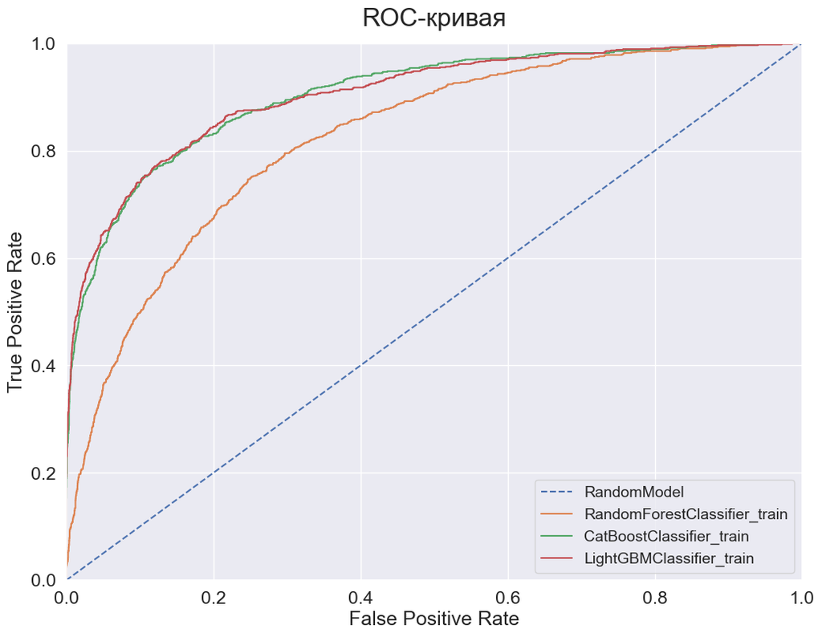

```python
plt.figure(figsize=[12, 9])

plt.plot([0, 1], [0, 1], linestyle='--', label='RandomModel')

RFC_probs = cross_val_predict(grid_RFC.best_estimator_, features_train_ohe,
                              target_train, cv=5, method='predict_proba')[:, 1]
fpr, tpr, thresholds = roc_curve(target_train, RFC_probs)
auc_roc_RFC_train = roc_auc_score(target_train, RFC_probs)
accuracy_RFC_train = accuracy_score(
    target_train, grid_RFC.predict(features_train_ohe))
plt.plot(fpr, tpr, label='RandomForestClassifier_train')

CBC_probs = cross_val_predict(grid_CBC.best_estimator_, features_train_ohe,
                              target_train, cv=5, method='predict_proba')[:, 1]
fpr, tpr, thresholds = roc_curve(target_train, CBC_probs)
auc_roc_CBC_train = roc_auc_score(target_train, CBC_probs)
accuracy_CBC_train = accuracy_score(
    target_train, grid_CBC.predict(features_train_ohe))
plt.plot(fpr, tpr, label='CatBoostClassifier_train')

LGBMC_probs = cross_val_predict(
    grid_LGBMC.best_estimator_, features_train_ohe, target_train, cv=5, method='predict_proba')[:, 1]
fpr, tpr, thresholds = roc_curve(target_train, LGBMC_probs)
auc_roc_LGBMC_train = roc_auc_score(target_train, LGBMC_probs)
accuracy_LGBMC_train = accuracy_score(
    target_train, grid_LGBMC.predict(features_train_ohe))
plt.plot(fpr, tpr, label='LightGBMClassifier_train')


plt.xlim([0, 1])
plt.ylim([0, 1])

plt.xlabel("False Positive Rate")
plt.ylabel("True Positive Rate")

plt.legend(loc='lower right', fontsize=14)

plt.title("ROC-кривая", fontsize=23, y=1.02)
plt.show()
plt.close()
```

### Проверим наилучшие параметры лучшей модели на тестовой выборке.

#### CatBoostClassifier

```python
%%time

model_CBC_test = CatBoostClassifier(learning_rate=0.16,
                                    depth=5,
                                    verbose=False,
                                    random_state=100423
                                    )

model_CBC_test.fit(features_train_ohe, target_train)


predict_proba = model_CBC_test.predict_proba(features_test_ohe)[:, 1]

ROC_AUC = round((roc_auc_score(target_test, predict_proba)), 3)
print('ROC_AUC модели "CatBoostClassifier" на тестовой выборке:', ROC_AUC)
```

```
ROC_AUC модели "CatBoostClassifier" на тестовой выборке: 0.914
CPU times: user 6.54 s, sys: 721 ms, total: 7.26 s
Wall time: 1.79 s
```

```python
y_pred = model_CBC_test.predict(features_test_ohe)

accuracy = accuracy_score(target_test, y_pred)
print("Accuracy модели 'CatBoostClassifier' :", round(accuracy, 3))
```

```
Accuracy модели 'CatBoostClassifier' : 0.925
```

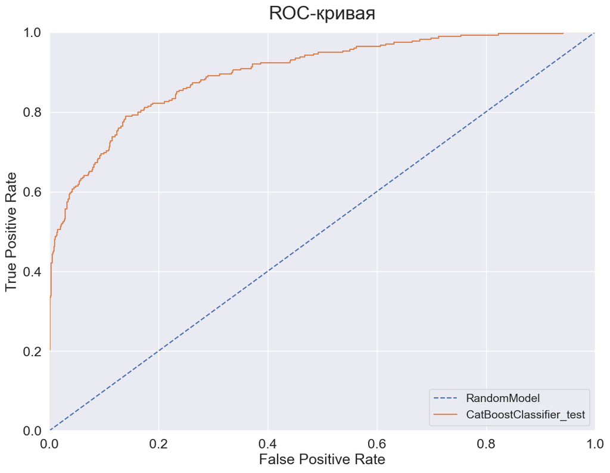

```python
plt.figure(figsize=[12, 9])

plt.plot([0, 1], [0, 1], linestyle='--', label='RandomModel')

probabilities_test = grid_CBC.best_estimator_.predict_proba(features_test_ohe)[
    :, 1]
probabilities_one_test = probabilities_test
fpr, tpr, thresholds = roc_curve(target_test, probabilities_one_test)
auc_roc_CBC_test = roc_auc_score(target_test, probabilities_test)
accuracy_CBC_test = accuracy_score(
    target_test, grid_CBC.predict(features_test_ohe))
plt.plot(fpr, tpr, label='CatBoostClassifier_test')

plt.xlim([0, 1])
plt.ylim([0, 1])

plt.xlabel("False Positive Rate")
plt.ylabel("True Positive Rate")

plt.legend(loc='lower right', fontsize=14)

plt.title("ROC-кривая", fontsize=23, y=1.02)
plt.show()
plt.close()
```

- Проведем анализ важности признаков на тестовой выборке. Это может нам позволить определить наиболее важные признаки для обучения, сконцентрироваться на них и улучшить метрику.

|  | feature | percent |
| --- | --- | --- |
| 0 | duration | 47.137626 |
| 1 | monthly_charges | 17.192497 |
| 2 | partner_Yes | 4.023399 |
| 3 | type_Two year | 3.892385 |
| 4 | multiple_lines_Yes | 2.766791 |
| 5 | online_backup_Yes | 2.335236 |
| 6 | payment_method_Credit card (automatic) | 2.127021 |
| 7 | device_protection_Yes | 2.120247 |
| 8 | streaming_movies_Yes | 2.082632 |
| 9 | type_One year | 2.036334 |
| 10 | dependents_Yes | 1.983175 |
| 11 | payment_method_Mailed check | 1.861131 |
| 12 | paperless_billing_Yes | 1.754225 |
| 13 | online_security_Yes | 1.748168 |
| 14 | senior_citizen_1 | 1.565026 |
| 15 | gender_Male | 1.450719 |
| 16 | tech_support_Yes | 1.219056 |
| 17 | payment_method_Electronic check | 1.160233 |
| 18 | streaming_tv_Yes | 1.120730 |
| 19 | internet_service_Fiber optic | 0.350875 |
| 20 | internet_service_No | 0.072495 |

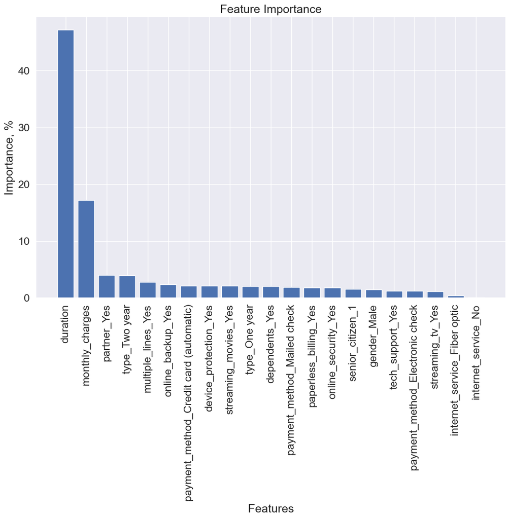

```python
# Создаем DataFrame с данными о важности признаков и сортируем его по убыванию важности
feat_import = pd.DataFrame(
    data={'feature': features_train_ohe.columns, 'percent': model_CBC_test.feature_importances_})
feat_import_sorted = feat_import.sort_values(
    'percent', ascending=False).reset_index(drop=True)
display(feat_import_sorted)

# Создаем график
plt.figure(figsize=(13, 8))
plt.bar(x=feat_import_sorted['feature'], height=feat_import_sorted['percent'])
plt.xticks(rotation=90)
plt.xlabel('Features')
plt.ylabel('Importance, %')
plt.title('Feature Importance')
plt.show()
plt.close()
```

##### Вывод:

- Из трех моделей на тренировочной выборке только две модели показали результат `ROC_AUC` >= 0.85:
  - CatBoostClassifier:
    - `ROC_AUC`=0.905 и `Accuracy`=0.904;
  - LightGBMClassifier:
    - `ROC_AUC`=0.904 и `Accuracy`=0.909;
- Самые лучшие рузультаты на тренировочной выборке показала модель `CatBoostClassifier`;
- На тестовой выборке модель `CatBoostClassifier` показала результат `ROC_AUC` = 0.914 и `Accuracy` = 0.925

# Отчет:

## Проект: Прототип модели машинного обучения для «Оператора связи "Ниединогоразрыва.ком"».

- Оператор связи «Ниединогоразрыва.ком» хочет научиться прогнозировать отток клиентов. Если выяснится, что пользователь планирует уйти, ему будут предложены промокоды и специальные условия. Команда оператора собрала персональные данные о некоторых клиентах, информацию об их тарифах и договорах.

### Описание услуг

Оператор предоставляет два основных типа услуг:

1. Стационарную телефонную связь. Возможно подключение телефонного аппарата к нескольким линиям одновременно.
2. Интернет. Подключение может быть двух типов: через телефонную линию (DSL*,* от англ. *digital subscriber line*, «цифровая абонентская линия») или оптоволоконный кабель (*Fiber optic*).

Также доступны такие услуги:

1. Интернет-безопасность: антивирус (*DeviceProtection*) и блокировка небезопасных сайтов (*OnlineSecurity*);
2. Выделенная линия технической поддержки (*TechSupport*);
3. Облачное хранилище файлов для резервного копирования данных (*OnlineBackup*);
4. Стриминговое телевидение (*StreamingTV*) и каталог фильмов (*StreamingMovies*).

За услуги клиенты могут платить каждый месяц или заключить договор на 1–2 года. Доступны различные способы расчёта и возможность получения электронного чека.

#### Нами были выполнены следующие этапы исследования:

1. Общий обзор данных:
- выведение сводной информации о датасетах;
- объединение датасетов для дальнейшей работы;
- корректировка названия столбов; выведение примера таблицы;
1. Провести предобработку данных:
- проверка на дубликаты;
- анализ пропусков и их обработка;
- унифицирование данных столбцов;
- удаление лишних столбцов;
- поиск аномальных значений в столбцах и их обработка;
- выведение статистических характеристик числовых признаков;
- построение гистограмм числовых признаков;
- построение "ящика с усами" для оценки выбросов;
- проверкам качественных данных на мультикколлениарность, которая может ослабить статистическую мощность модели;
- выявление взаимосвязи между всеми парами числовых признаков; выявление Phik корреляции между бинарными и категориальными признаками;
- проверка на дубликаты после проведенной обработки данных и их удаление;
1. Анализ данных:
- объявление переменных `target` и `features`;
- разделение датасета на тренировочную и тестовую выборку;
- применение *One-Hot Encoder* прямого метода кодирования данных (*One-Hot Encoder*);
- обучение моделей осуществлялось на следующих признаках: 'monthly_charges', 'duration', 'type_One year', 'type_Two year', 'paperless_billing_Yes', 'payment_method_Credit card (automatic)', 'payment_method_Electronic check', 'payment_method_Mailed check', 'gender_Male', 'senior_citizen_1', 'partner_Yes', 'dependents_Yes', 'internet_service_Fiber optic', 'internet_service_No', 'online_security_Yes', 'online_backup_Yes', 'device_protection_Yes', 'tech_support_Yes', 'streaming_tv_Yes', 'streaming_movies_Yes', 'multiple_lines_Yes';
- обучение и подбор лучших гиперпараметров для моделей RandomForestClassifier [GridSearchCV], CatBoost [закодированные признаки] [GridSearchCV], LightGBMClassifier [GridSearchCV];
- построение ROC-кривых на тренировочной выборке для выше перечисленных моделей;
- проверка наилучших параметров лучшей модели (CatBoost [закодированные признаки] [GridSearchCV]) на тестовой выборке и построение ROC-кривой на тестовой выборке для данной модели;
- проведение анализа важности признаков на тестовой выборке, что может нам позволить определить наиболее важные признаки для обучения и сконцентрироваться на них, и улучшить метрику);
1. Вывод и заключение.

#### Нами были выполнены все условия:

1. Использовать бизнес-метрики:
- Основная метрика: AUC-ROC (метрика, которая учитывает возможность балансировать между false posititve и false negative.); целевое значение AUC-ROC >= 0.85
- Дополнительная метрика: Accuracy;
1. Использовать значение RANDOM_STATE = 100423;
2. Размер тестовой выборки: test_size = 0.25;
3. Проверить корреляцию числовых и качественных признаков на наличие мультиколлинеарности;
4. Рассмотреть как минимум две (а лучше три) модели машинного обучения, например случайный лес и градиентный бустинг. При использовании только двух моделей нельзя использовать две вариации градиентного бустинга. Модели, которые мы использовали:
- RandomForestClassifier [GridSearchCV];
- CatBoostClassifier [закодированные признаки] [GridSearchCV];
- LightGBMClassifier [GridSearchCV];

#### Заключение:

Для достажения поставленной цели: "Построить модель для прогнозирования оттока клиентов.", мы можем рекомендовать модель CatBoostClassifier со следующими гиперпараметрами:

- learning_rate=0.16;
- depth=5;
- verbose=False;
- random_state=100423.

Все этапы проекта были важны. Однако, по нашему мнению ключевым этапом, который позволил добиться высокого значения метрики, был этап предобработки данных. Потому что именно он является краеугольным камнем любого анализа.